# INVESTIGATE A DATASET

The following lines of code was dedicated to analyze the No-Show-Appointments data in order to assess and complete the project 2. I started by looking at the general traits of the data, then I performed the necessary wrangling and cleaning. At last, I plotted some graphs for better visualization and conclusions.

## Some questions to be analyzed:

### 1. Which one has missed more medical appointments, man or woman?

### 2. Is there a relationship between no-show and social factors such as scholarship, hipertension, diabetes, alcoholism?

### 3. What's the impact of SMS received in no-show ratio?

### 4. Is there a specific day or month where people tend not to show up in appointments?

```python
#load packages and dataset to check general details
import pandas as pd
import numpy as np
import matplotlib.pyplot as plt
import seaborn as sns
```

```python
#Load dataset to check general details
df = pd.read_csv('noshowdata.csv')
df.head()
```

|  | PatientId | AppointmentID | Gender | ScheduledDay | AppointmentDay | Age | Neighbourhood | Scholarship | Hipertension | Diabetes | Alcoholism | Handcap | SMS_received | No-show |
| --- | --- | --- | --- | --- | --- | --- | --- | --- | --- | --- | --- | --- | --- | --- |
| 0 | 2.987250e+13 | 5642903 | F | 2016-04-29T18:38:08Z | 2016-04-29T00:00:00Z | 62 | JARDIM DA PENHA | 0 | 1 | 0 | 0 | 0 | 0 | No |
| 1 | 5.589978e+14 | 5642503 | M | 2016-04-29T16:08:27Z | 2016-04-29T00:00:00Z | 56 | JARDIM DA PENHA | 0 | 0 | 0 | 0 | 0 | 0 | No |
| 2 | 4.262962e+12 | 5642549 | F | 2016-04-29T16:19:04Z | 2016-04-29T00:00:00Z | 62 | MATA DA PRAIA | 0 | 0 | 0 | 0 | 0 | 0 | No |
| 3 | 8.679512e+11 | 5642828 | F | 2016-04-29T17:29:31Z | 2016-04-29T00:00:00Z | 8 | PONTAL DE CAMBURI | 0 | 0 | 0 | 0 | 0 | 0 | No |
| 4 | 8.841186e+12 | 5642494 | F | 2016-04-29T16:07:23Z | 2016-04-29T00:00:00Z | 56 | JARDIM DA PENHA | 0 | 1 | 1 | 0 | 0 | 0 | No |

```python
#Check data info - no null data was detected
df.info()
```

```
<class 'pandas.core.frame.DataFrame'>
RangeIndex: 110527 entries, 0 to 110526
Data columns (total 14 columns):
PatientId         110527 non-null float64
AppointmentID     110527 non-null int64
Gender            110527 non-null object
ScheduledDay      110527 non-null object
AppointmentDay    110527 non-null object
Age               110527 non-null int64
Neighbourhood     110527 non-null object
Scholarship       110527 non-null int64
Hipertension      110527 non-null int64
Diabetes          110527 non-null int64
Alcoholism        110527 non-null int64
Handcap           110527 non-null int64
SMS_received      110527 non-null int64
No-show           110527 non-null object
dtypes: float64(1), int64(8), object(5)
memory usage: 11.8+ MB
```

```python
#Check data statistics
df.describe()
```

|  | PatientId | AppointmentID | Age | Scholarship | Hipertension | Diabetes | Alcoholism | Handcap | SMS_received |
| --- | --- | --- | --- | --- | --- | --- | --- | --- | --- |
| count | 1.105270e+05 | 1.105270e+05 | 110527.000000 | 110527.000000 | 110527.000000 | 110527.000000 | 110527.000000 | 110527.000000 | 110527.000000 |
| mean | 1.474963e+14 | 5.675305e+06 | 37.088874 | 0.098266 | 0.197246 | 0.071865 | 0.030400 | 0.022248 | 0.321026 |
| std | 2.560949e+14 | 7.129575e+04 | 23.110205 | 0.297675 | 0.397921 | 0.258265 | 0.171686 | 0.161543 | 0.466873 |
| min | 3.921784e+04 | 5.030230e+06 | -1.000000 | 0.000000 | 0.000000 | 0.000000 | 0.000000 | 0.000000 | 0.000000 |
| 25% | 4.172614e+12 | 5.640286e+06 | 18.000000 | 0.000000 | 0.000000 | 0.000000 | 0.000000 | 0.000000 | 0.000000 |
| 50% | 3.173184e+13 | 5.680573e+06 | 37.000000 | 0.000000 | 0.000000 | 0.000000 | 0.000000 | 0.000000 | 0.000000 |
| 75% | 9.439172e+13 | 5.725524e+06 | 55.000000 | 0.000000 | 0.000000 | 0.000000 | 0.000000 | 0.000000 | 1.000000 |
| max | 9.999816e+14 | 5.790484e+06 | 115.000000 | 1.000000 | 1.000000 | 1.000000 | 1.000000 | 4.000000 | 1.000000 |

```python
#Check data types
df.dtypes
```

```
PatientId         float64
AppointmentID       int64
Gender             object
ScheduledDay       object
AppointmentDay     object
Age                 int64
Neighbourhood      object
Scholarship         int64
Hipertension        int64
Diabetes            int64
Alcoholism          int64
Handcap             int64
SMS_received        int64
No-show            object
dtype: object
```

```python
#Remove useless columns for my analysis
df.drop(['PatientId', 'AppointmentID', 'Neighbourhood'], axis=1, inplace=True)
```

```python
#Confirm columns removal
df.head()
```

|  | Gender | ScheduledDay | AppointmentDay | Age | Scholarship | Hipertension | Diabetes | Alcoholism | Handcap | SMS_received | No-show |
| --- | --- | --- | --- | --- | --- | --- | --- | --- | --- | --- | --- |
| 0 | F | 2016-04-29T18:38:08Z | 2016-04-29T00:00:00Z | 62 | 0 | 1 | 0 | 0 | 0 | 0 | No |
| 1 | M | 2016-04-29T16:08:27Z | 2016-04-29T00:00:00Z | 56 | 0 | 0 | 0 | 0 | 0 | 0 | No |
| 2 | F | 2016-04-29T16:19:04Z | 2016-04-29T00:00:00Z | 62 | 0 | 0 | 0 | 0 | 0 | 0 | No |
| 3 | F | 2016-04-29T17:29:31Z | 2016-04-29T00:00:00Z | 8 | 0 | 0 | 0 | 0 | 0 | 0 | No |
| 4 | F | 2016-04-29T16:07:23Z | 2016-04-29T00:00:00Z | 56 | 0 | 1 | 1 | 0 | 0 | 0 | No |

```python
#Locate row where Age is equal -1 [unreal]
age1 = df[df['Age'] == -1]
age1
```

|  | Gender | ScheduledDay | AppointmentDay | Age | Scholarship | Hipertension | Diabetes | Alcoholism | Handcap | SMS_received | No-show |
| --- | --- | --- | --- | --- | --- | --- | --- | --- | --- | --- | --- |
| 99832 | F | 2016-06-06T08:58:13Z | 2016-06-06T00:00:00Z | -1 | 0 | 0 | 0 | 0 | 0 | 0 | No |

```python
#Drop row where Age is equal -1
df.drop([99832], inplace=True)
```

```python
#Check data after dropping Age = -1
age2 = df[df['Age'] == -1]
age2
```

|  | Gender | ScheduledDay | AppointmentDay | Age | Scholarship | Hipertension | Diabetes | Alcoholism | Handcap | SMS_received | No-show |
| --- | --- | --- | --- | --- | --- | --- | --- | --- | --- | --- | --- |

```python
#Count how many showed up and how many no show
df['No-show'].value_counts()
```

```
No     88207
Yes    22319
Name: No-show, dtype: int64
```

```python
#Count how many people were men or women
df['Gender'].value_counts()
```

```
F    71839
M    38687
Name: Gender, dtype: int64
```

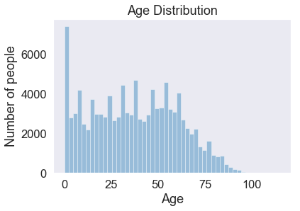

```python
#Age distribution visualization using Seaborn
sns.distplot(df.Age, norm_hist=False, kde=False, bins=50)
sns.set_style("dark")
sns.set_context("notebook", font_scale=1.5, rc={"lines.linewidth": 2.5})
plt.title('Age Distribution')
plt.xlabel('Age')
plt.ylabel('Number of people')
```

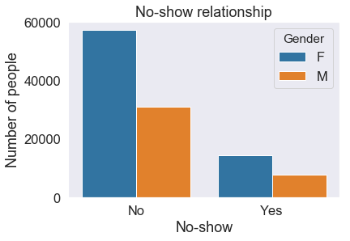

```python
#No show relationship between men and women
sns.countplot(x='No-show', hue="Gender", data=df)
sns.set_style("dark")
sns.set_context("notebook", font_scale=1.5, rc={"lines.linewidth": 2.5})
plt.title('No-show relationship')
plt.ylabel('Number of people')
```

```python
#No show ratio between men
many = ((df['Gender'] == "M") | (df['No-show'] == "Yes")).sum()
mann = ((df['Gender'] == "M") | (df['No-show'] == "No")).sum()
man_ratio = many/(mann+many)
man_ratio
```

```
0.3570801471721633
```

```python
#No show ratio between women
womy = ((df['Gender'] == "F") | (df['No-show'] == "Yes")).sum()
womn = ((df['Gender'] == "F") | (df['No-show'] == "No")).sum()
woman_ratio = womy/(womn+womy)
woman_ratio
```

```
0.43628985825130917
```

### Answer 1

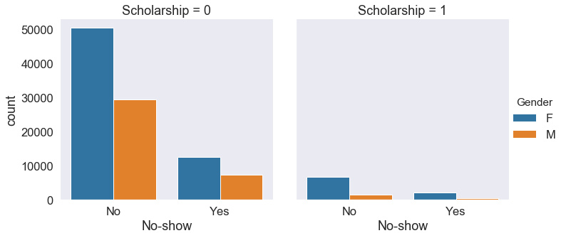

```python
#No show relationship between man and woman with regard to his/her scholarship
sns.catplot(x='No-show', hue="Gender", col="Scholarship", data=df, kind="count")
sns.set_style("dark")
sns.set_context("notebook", font_scale=1.5, rc={"lines.linewidth": 2.5})
```

```python
#People with Scholatship = 1 ratio between no-show
s1y = ((df['Scholarship'] == 1) | (df['No-show'] == "Yes")).sum()
s1n =((df['Scholarship'] == 1) | (df['No-show'] == "No")).sum()
s1_ratio = s1y/(s1y+s1n)
s1_ratio
```

```
0.2521027787160075
```

```python
#People with Scholarship = 0 ratio between no-show
s0y = ((df['Scholarship'] == 0) | (df['No-show'] == "Yes")).sum()
s0n = ((df['Scholarship'] == 0) | (df['No-show'] == "No")).sum()
s0_ratio = s0y/(s0n+s0y)
s0_ratio
```

```
0.4864290098053675
```

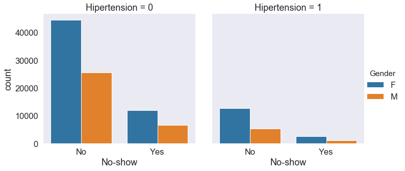

```python
#No show relationship between man and woman and if he/she has hipertension
sns.catplot(x='No-show', hue="Gender", col="Hipertension", data=df, kind="count")
sns.set_style("dark")
sns.set_context("notebook", font_scale=1.5, rc={"lines.linewidth": 2.5})
```

```python
#People with Hipertension [= 1] ratio between no-show
h1y = ((df['Hipertension'] == 1) | (df['No-show'] == "Yes")).sum()
h1n =((df['Hipertension'] == 1) | (df['No-show'] == "No")).sum()
h1_ratio = h1y/(h1y+h1n)
h1_ratio
```

```
0.30491131817391764
```

```python
#People without Hipertension [= 0] ratio between no-show
h0y = ((df['Hipertension'] == 0) | (df['No-show'] == "Yes")).sum()
h0n = ((df['Hipertension'] == 0) | (df['No-show'] == "No")).sum()
h0_ratio = h0y/(h0n+h0y)
h0_ratio
```

```
0.4642235170714325
```

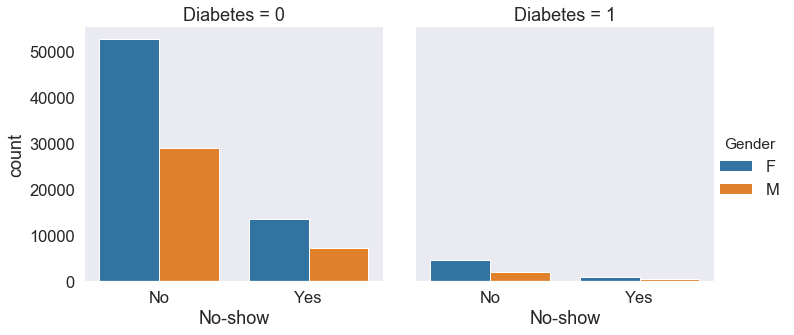

```python
#No show relationship between man and woman and if he/she has diabetes
sns.catplot(x='No-show', hue="Gender", col="Diabetes", data=df, kind="count")
sns.set_style("dark")
sns.set_context("notebook", font_scale=1.5, rc={"lines.linewidth": 2.5})
```

```python
#People with Diabetes [= 1] ratio between no-show
d1y = ((df['Diabetes'] == 1) | (df['No-show'] == "Yes")).sum()
d1n =((df['Diabetes'] == 1) | (df['No-show'] == "No")).sum()
d1_ratio = d1y/(d1y+d1n)
d1_ratio
```

```
0.2433716837316091
```

```python
#People without Diabetes [= 0] ratio between no-show
d0y = ((df['Diabetes'] == 0) | (df['No-show'] == "Yes")).sum()
d0n = ((df['Diabetes'] == 0) | (df['No-show'] == "No")).sum()
d0_ratio = d0y/(d0n+d0y)
d0_ratio
```

```
0.48807417800280606
```

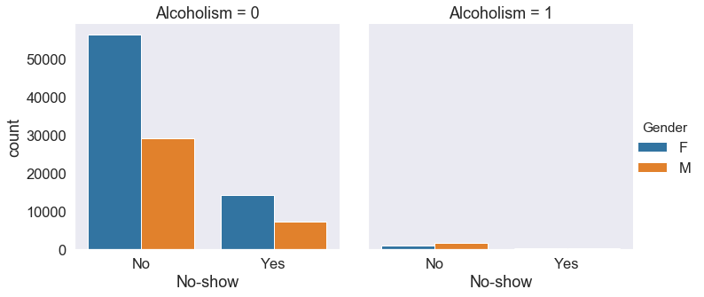

```python
#No show relationship between man and woman and if he/she has alcoholism
sns.catplot(x='No-show', hue="Gender", col="Alcoholism", data=df, kind="count")
sns.set_style("dark")
sns.set_context("notebook", font_scale=1.5, rc={"lines.linewidth": 2.5})
```

```python
#People with Alcoholism [= 1] ratio between no-show
a1y = ((df['Alcoholism'] == 1) | (df['No-show'] == "Yes")).sum()
a1n =((df['Alcoholism'] == 1) | (df['No-show'] == "No")).sum()
a1_ratio = a1y/(a1y+a1n)
a1_ratio
```

```
0.2195353247984827
```

```python
#People without Alcoholism [= 0] ratio between no-show
a0y = ((df['Alcoholism'] == 0) | (df['No-show'] == "Yes")).sum()
a0n = ((df['Alcoholism'] == 0) | (df['No-show'] == "No")).sum()
a0_ratio = a0y/(a0n+a0y)
a0_ratio
```

```
0.495392572993036
```

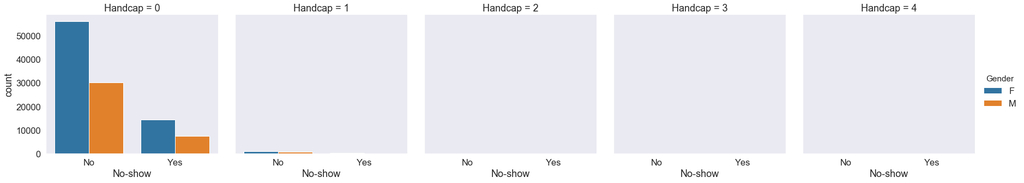

```python
#No show relationship between man and woman with regard to  his/her handcap
sns.catplot(x='No-show', hue="Gender", col="Handcap", data=df, kind="count")
sns.set_style("dark")
sns.set_context("notebook", font_scale=1.5, rc={"lines.linewidth": 2.5})
```

### Answer 2

#### 2. In general people diagnosed with any of the diseases and/or illness in the dataframe such as: hipertension, diabetes and alcoholism tend to miss less appointments. In each case, we can see that no-show ratio [no-show = "yes"] for these groups is low: hipertension (30.4%), diabetes (24.3%) and alcoholism (21.9%). Maybe It indicates that people that are aware of his/her illness are more careful about his/her own health and go to the doctor more frequently.

#### 3. Handcap data is strongly based on one variable [handicap=0], so it's risky concludes that people with no disabilities or slightly move impairment are less likely to miss appointments.

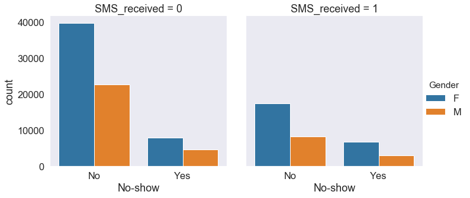

```python
#No show relationship between man and woman and if he/she has received SMS
sns.catplot(x='No-show', hue="Gender", col="SMS_received", data=df, kind="count")
sns.set_style("dark")
sns.set_context("notebook", font_scale=1.5, rc={"lines.linewidth": 2.5})
```

```python
#People that received SMS [= 1] ratio between no-show
r1y = ((df['SMS_received'] == 1) | (df['No-show'] == "Yes")).sum()
r1n =((df['SMS_received'] == 1) | (df['No-show'] == "No")).sum()
r1_ratio = r1n/(r1y+r1n)#inverse
r1_ratio
```

```
0.6711344583858418
```

```python
#People that havent received SMS [= 0] ratio between no-show
r0y = ((df['SMS_received'] == 0) | (df['No-show'] == "Yes")).sum()
r0n =((df['SMS_received'] == 0) | (df['No-show'] == "No")).sum()
r0_ratio = r0n/(r0y+r0n)#inverse
r0_ratio
```

```
0.5428786980654201
```

```python
#Split AppointmentDay date into year, month, day, hour...and converting these data to integers
df_date = df['AppointmentDay'].str.split("-", expand=True)
df['Year_Ap'] = df_date[0].astype(int)
df['Month_Ap'] = df_date[1].astype(int)
df['Day_Ap'] = df_date[2]
```

```python
#Split day from hour
df_date2 = df['Day_Ap'].str.split("T", expand=True)
```

```python
#Split day from hour and converting to integer
df['Day_Ap'] = df_date2[0].astype(int)
```

```python
#Check data types for new columns
df.dtypes
```

```
Gender            object
ScheduledDay      object
AppointmentDay    object
Age                int64
Scholarship        int64
Hipertension       int64
Diabetes           int64
Alcoholism         int64
Handcap            int64
SMS_received       int64
No-show           object
Year_Ap            int32
Month_Ap           int32
Day_Ap             int32
dtype: object
```

```python
#Split day from hour
df['Hour_Ap'] = df_date2[1]
```

```python
#Appointment hour is all the same, every one is 00:00 [useless]
df['Hour_Ap'].head()
```

```
0    00:00:00Z
1    00:00:00Z
2    00:00:00Z
3    00:00:00Z
4    00:00:00Z
Name: Hour_Ap, dtype: object
```

```python
#Check if new columns were created
df.head()
```

|  | Gender | ScheduledDay | AppointmentDay | Age | Scholarship | Hipertension | Diabetes | Alcoholism | Handcap | SMS_received | No-show | Year_Ap | Month_Ap | Day_Ap | Hour_Ap |
| --- | --- | --- | --- | --- | --- | --- | --- | --- | --- | --- | --- | --- | --- | --- | --- |
| 0 | F | 2016-04-29T18:38:08Z | 2016-04-29T00:00:00Z | 62 | 0 | 1 | 0 | 0 | 0 | 0 | No | 2016 | 4 | 29 | 00:00:00Z |
| 1 | M | 2016-04-29T16:08:27Z | 2016-04-29T00:00:00Z | 56 | 0 | 0 | 0 | 0 | 0 | 0 | No | 2016 | 4 | 29 | 00:00:00Z |
| 2 | F | 2016-04-29T16:19:04Z | 2016-04-29T00:00:00Z | 62 | 0 | 0 | 0 | 0 | 0 | 0 | No | 2016 | 4 | 29 | 00:00:00Z |
| 3 | F | 2016-04-29T17:29:31Z | 2016-04-29T00:00:00Z | 8 | 0 | 0 | 0 | 0 | 0 | 0 | No | 2016 | 4 | 29 | 00:00:00Z |
| 4 | F | 2016-04-29T16:07:23Z | 2016-04-29T00:00:00Z | 56 | 0 | 1 | 1 | 0 | 0 | 0 | No | 2016 | 4 | 29 | 00:00:00Z |

```python
#Filtering data where no-show = "yes"
mm = df[df['No-show'] == "Yes"]
mm.head()
```

|  | Gender | ScheduledDay | AppointmentDay | Age | Scholarship | Hipertension | Diabetes | Alcoholism | Handcap | SMS_received | No-show | Year_Ap | Month_Ap | Day_Ap | Hour_Ap |
| --- | --- | --- | --- | --- | --- | --- | --- | --- | --- | --- | --- | --- | --- | --- | --- |
| 6 | F | 2016-04-27T15:05:12Z | 2016-04-29T00:00:00Z | 23 | 0 | 0 | 0 | 0 | 0 | 0 | Yes | 2016 | 4 | 29 | 00:00:00Z |
| 7 | F | 2016-04-27T15:39:58Z | 2016-04-29T00:00:00Z | 39 | 0 | 0 | 0 | 0 | 0 | 0 | Yes | 2016 | 4 | 29 | 00:00:00Z |
| 11 | M | 2016-04-26T08:44:12Z | 2016-04-29T00:00:00Z | 29 | 0 | 0 | 0 | 0 | 0 | 1 | Yes | 2016 | 4 | 29 | 00:00:00Z |
| 17 | F | 2016-04-28T09:28:57Z | 2016-04-29T00:00:00Z | 40 | 1 | 0 | 0 | 0 | 0 | 0 | Yes | 2016 | 4 | 29 | 00:00:00Z |
| 20 | F | 2016-04-27T07:51:14Z | 2016-04-29T00:00:00Z | 30 | 0 | 0 | 0 | 0 | 0 | 0 | Yes | 2016 | 4 | 29 | 00:00:00Z |

```python
#Counting the months for no-show = "yes"
mm.Month_Ap.value_counts()
```

```
5    16804
6     4882
4      633
Name: Month_Ap, dtype: int64
```

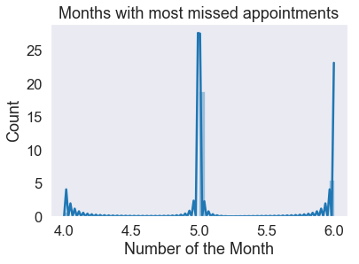

```python
#Month distribution visualization using Seaborn based on no-show
sns.distplot(mm.Month_Ap, norm_hist=False, kde=True, bins=50)
sns.set_style("dark")
sns.set_context("notebook", font_scale=1.5, rc={"lines.linewidth": 2.5})
plt.title('Months with most missed appointments')
plt.xlabel('Number of the Month')
plt.ylabel('Count')
```

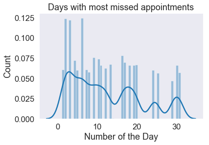

```python
#Day distribution visualization using Seaborn based on no-show
sns.distplot(mm.Day_Ap, norm_hist=False, kde=True, bins=50)
sns.set_style("dark")
sns.set_context("notebook", font_scale=1.5, rc={"lines.linewidth": 2.5})
plt.title('Days with most missed appointments')
plt.xlabel('Number of the Day')
plt.ylabel('Count')
```

### Answer 4

#### By splitting appointment's date in month and day, we can see that people are more likely to miss appointments in May [month=5] than in April or June [month=4 and 6] as showed above in histogram plot. In terms of day, days in the beggining of the month are more frequent for people to miss appointments, mainly up to day 10, as showed in last histogram plot.

```python
df.head()
```

|  | Gender | ScheduledDay | AppointmentDay | Age | Scholarship | Hipertension | Diabetes | Alcoholism | Handcap | SMS_received | No-show | Year_Ap | Month_Ap | Day_Ap | Hour_Ap |
| --- | --- | --- | --- | --- | --- | --- | --- | --- | --- | --- | --- | --- | --- | --- | --- |
| 0 | F | 2016-04-29T18:38:08Z | 2016-04-29T00:00:00Z | 62 | 0 | 1 | 0 | 0 | 0 | 0 | No | 2016 | 4 | 29 | 00:00:00Z |
| 1 | M | 2016-04-29T16:08:27Z | 2016-04-29T00:00:00Z | 56 | 0 | 0 | 0 | 0 | 0 | 0 | No | 2016 | 4 | 29 | 00:00:00Z |
| 2 | F | 2016-04-29T16:19:04Z | 2016-04-29T00:00:00Z | 62 | 0 | 0 | 0 | 0 | 0 | 0 | No | 2016 | 4 | 29 | 00:00:00Z |
| 3 | F | 2016-04-29T17:29:31Z | 2016-04-29T00:00:00Z | 8 | 0 | 0 | 0 | 0 | 0 | 0 | No | 2016 | 4 | 29 | 00:00:00Z |
| 4 | F | 2016-04-29T16:07:23Z | 2016-04-29T00:00:00Z | 56 | 0 | 1 | 1 | 0 | 0 | 0 | No | 2016 | 4 | 29 | 00:00:00Z |

```python
#Explore the trend between social aspects: age, scholarship, hipertension, diabetes, alcoholism, handcap.
dfp = df.drop(['Gender', 'ScheduledDay', 'AppointmentDay', 'SMS_received', 'No-show', 'Year_Ap', 'Month_Ap', 'Day_Ap', 'Hour_Ap'], axis=1)
```

```python
#Check dropna
dfp.head()
```

|  | Age | Scholarship | Hipertension | Diabetes | Alcoholism | Handcap |
| --- | --- | --- | --- | --- | --- | --- |
| 0 | 62 | 0 | 1 | 0 | 0 | 0 |
| 1 | 56 | 0 | 0 | 0 | 0 | 0 |
| 2 | 62 | 0 | 0 | 0 | 0 | 0 |
| 3 | 8 | 0 | 0 | 0 | 0 | 0 |
| 4 | 56 | 0 | 1 | 1 | 0 | 0 |

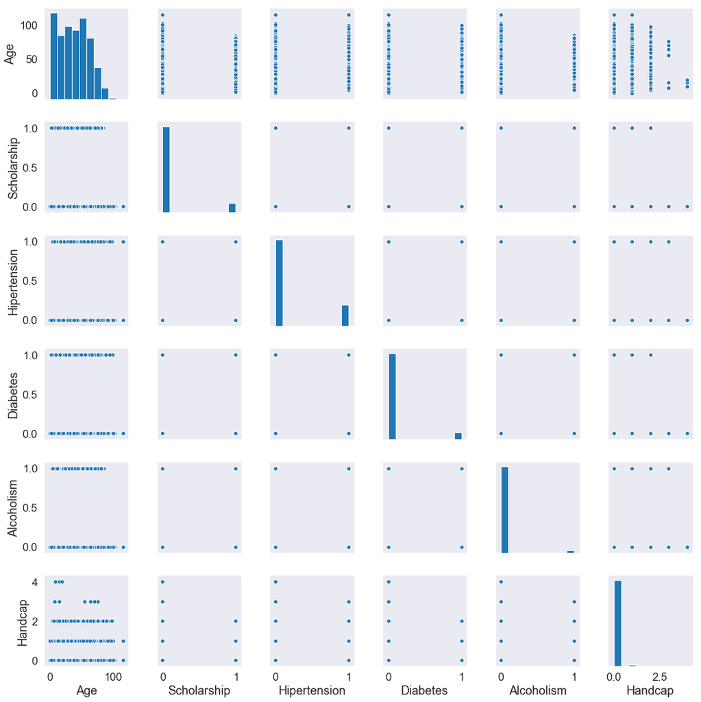

```python
#Pairplot of social aspects
sns.pairplot(dfp)
#relationship is not clear, most variables are binary format [0 or 1], that's why this visualization is not recommended.
```

```python
#Explore 2d plot with data that's not binary: age, month_ap, day_ap.
df2dplot = df.drop(['Gender', 'ScheduledDay', 'AppointmentDay', 'Scholarship','Hipertension', 'Diabetes', 'Alcoholism', 'Handcap', 'SMS_received', 'No-show', 'Year_Ap', 'Hour_Ap'], axis=1)
```

```python
#Check dropna
df2dplot.head()
```

|  | Age | Month_Ap | Day_Ap |
| --- | --- | --- | --- |
| 0 | 62 | 4 | 29 |
| 1 | 56 | 4 | 29 |
| 2 | 62 | 4 | 29 |
| 3 | 8 | 4 | 29 |
| 4 | 56 | 4 | 29 |

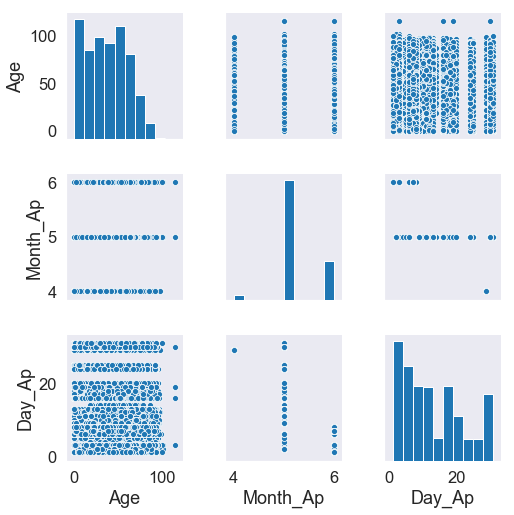

```python
#Pairplot of non-binary data
sns.pairplot(df2dplot)
#Same conslusions we got from previous plots: histogram and bar.
```

```python
#Split ScheduleDay date into year, month, day, hour...and converting these data to integers
df_dates = df['ScheduledDay'].str.split("-", expand=True)
df['Year_Sc'] = df_dates[0].astype(int)
df['Month_Sc'] = df_dates[1].astype(int)
df['Day_Sc'] = df_dates[2]
```

```python
#Split day from hour
df_dates2 = df['Day_Sc'].str.split("T", expand=True)
```

```python
#Split day from hour and converting to integer
df['Day_Sc'] = df_dates2[0].astype(int)
```

```python
#Split day from hour
df['Hour_Sc'] = df_dates2[1]
```

```python
df.head()
```

|  | Gender | ScheduledDay | AppointmentDay | Age | Scholarship | Hipertension | Diabetes | Alcoholism | Handcap | SMS_received | No-show | Year_Ap | Month_Ap | Day_Ap | Hour_Ap | Year_Sc | Month_Sc | Day_Sc | Hour_Sc |
| --- | --- | --- | --- | --- | --- | --- | --- | --- | --- | --- | --- | --- | --- | --- | --- | --- | --- | --- | --- |
| 0 | F | 2016-04-29T18:38:08Z | 2016-04-29T00:00:00Z | 62 | 0 | 1 | 0 | 0 | 0 | 0 | No | 2016 | 4 | 29 | 00:00:00Z | 2016 | 4 | 29 | 18:38:08Z |
| 1 | M | 2016-04-29T16:08:27Z | 2016-04-29T00:00:00Z | 56 | 0 | 0 | 0 | 0 | 0 | 0 | No | 2016 | 4 | 29 | 00:00:00Z | 2016 | 4 | 29 | 16:08:27Z |
| 2 | F | 2016-04-29T16:19:04Z | 2016-04-29T00:00:00Z | 62 | 0 | 0 | 0 | 0 | 0 | 0 | No | 2016 | 4 | 29 | 00:00:00Z | 2016 | 4 | 29 | 16:19:04Z |
| 3 | F | 2016-04-29T17:29:31Z | 2016-04-29T00:00:00Z | 8 | 0 | 0 | 0 | 0 | 0 | 0 | No | 2016 | 4 | 29 | 00:00:00Z | 2016 | 4 | 29 | 17:29:31Z |
| 4 | F | 2016-04-29T16:07:23Z | 2016-04-29T00:00:00Z | 56 | 0 | 1 | 1 | 0 | 0 | 0 | No | 2016 | 4 | 29 | 00:00:00Z | 2016 | 4 | 29 | 16:07:23Z |

```python
#Explore 2d plot with data that's not binary: scheduledday and appointment day.
df2dplot2 = df.drop(['Gender', 'ScheduledDay', 'AppointmentDay', 'Age', 'Scholarship','Hipertension', 'Diabetes', 'Alcoholism', 'Handcap', 'SMS_received', 'No-show', 'Year_Ap', 'Hour_Ap', 'Year_Sc', 'Hour_Sc'], axis=1)
```

```python
#Check dropna
df2dplot2.head()
```

|  | Month_Ap | Day_Ap | Month_Sc | Day_Sc |
| --- | --- | --- | --- | --- |
| 0 | 4 | 29 | 4 | 29 |
| 1 | 4 | 29 | 4 | 29 |
| 2 | 4 | 29 | 4 | 29 |
| 3 | 4 | 29 | 4 | 29 |
| 4 | 4 | 29 | 4 | 29 |

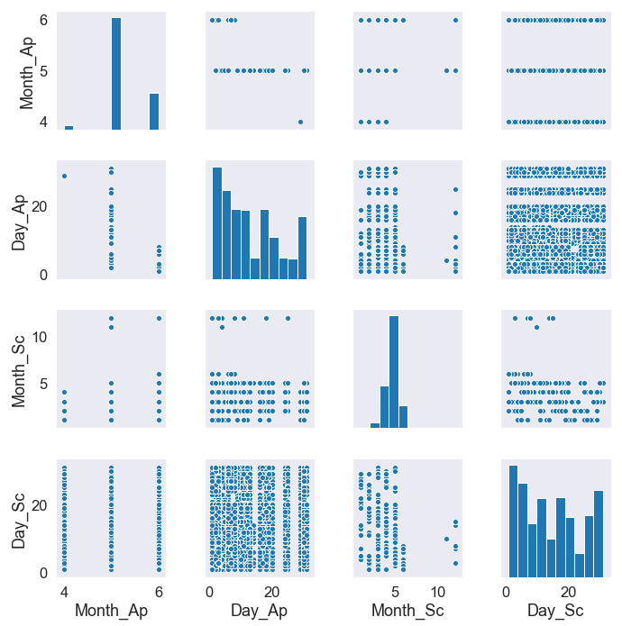

```python
#Pairplot of non-binary data: scheduled day and appointment day.
sns.pairplot(df2dplot2)
#Same conslusions we got from previous plots: histogram and bar.
```

### Final Remarks

#### 3. Direct and trend line proved to be difficult to achieve plotting this dataframe, as a proof of work, 3 pairplot were plotted using seaborn: one for social aspects, one for appointment dates and one for scheduled dates, all of them were either unconclusive or revealed the same conclusion we got from previous histograms or bar plots.